# Estatística para ciência de dados

**Aluno:** Eduardo Façanha Dutra

**Matrícula:** 2016473

**Resolução do trabalho 02: Ex-Teste-usabilidade-Gera-Graficos - PP**

1ª Questão: Considere que testadores analisaram na etapa “atende aos requisitos?” se um participante teria a idade requerida (entre 18 e 24 anos). Explique o que significaria, em um gráfico XY, se ter no eixo Y idade e no eixo X o perfil da amostra (número de indivíduos selecionados)?

Resposta:

Um gráfico XY da [idade requerida] necessitaria que no eixo x seja representada a [idade] do perfil da amostra, já que a variável [idade requerida] é dependente da variável [idade].

**2ª Questão: Considere que todos os indivíduos selecionados irão realizar as mesmas atividades usando cada um dos sistemas. Pede-se:**

[output not shown]

**Resposta:**

```
1- A distribuição aleatória de atividades por voluntário evita, ou mitiga, o efeito de viés nos efeitos em observação.

2- Atividades dependentes: Alguma atividade pode afetar de alguma forma a execução da próxima atividade;
  Nível de dificuldade: Atividades mais complexas que são deixadas para o final podem ser executadas com menor rigor, devido ao cansaço ou pressa do voluntário;
3- Diminuição da complexidade das atividades e compensar a falta de profundidade das atividades com o aumento no número de amostras, oferecer recompensas de alguma natureza aos voluntários, trabalhs em grupo.
```

**3ª. Questão. Sobre a etapa “receber treinamento”, considere que ela se refere à forma como um experimento é esperado ser conduzido pelos investigadores. Por exemplo, todos os participantes devem receber o mesmo treinamento sobre cada sistema. O treinamento consistiria no testador mostrar a utilidade e estrutura do sistema, antes do usuário usar o sistema. Depois o testador diria que passaria X atividades para o usuário realizar usando o sistema. Para o exemplo em estudo, dê exemplos de variáveis que podem ser riscos para os resultados se os indivíduos não receberem este treinamento.**

Resposta:

O avaliador não terá a certeza de que os dados coletados serão confiáveis para se extrair alguma conclusão, o que comprometerá toda a pesquisa.

**4ª. Questão. Para cada um dos 4 problemas dados a seguir pede-se:**

1. defina a hipótese para um modelo de pesquisa da preferência de usuários por um sistema interativo;
2. coloque a amostra coletada para o problema no excel;
3. Faça a análise dos dados, usando dois gráficos: boxplot (gráfico de caixa), que é um gráfico utilizado para avaliar a distribuição empírica dos dados) e histograma, que é um gráfico de frequência, que tem como objetivo ilustrar como uma determinada amostra ou população de dados está distribuída)

1- Problema: analisar as preferências de usuários entre dois sistemas: prefsAB.cvs

Desenvolvimento:

a)Hipóteses:

“Há diferença na preferência entre os sistemas A e B?”

b)Leitura dos dados:

```r
library(readr)
#install.packages("tidyverse") #<--- caso tidyverse não esteja instalado
library(tidyverse)
#A leitura dos dados é realizado excluindo-se a primeira coluna, pois se trata de um sequêncial sem significado para o problema em questão. Além disso é realizado o "factor" dos dados para que seja possível realizar a contagem dos valores
prefsAB <- as.tibble(read_csv("Dados/prefsAB.csv",col_types = cols(Pref = col_factor(levels = c("A","B")), Subject = col_skip())))
```

```
`as.tibble()` is deprecated as of tibble 2.0.0.
Please use `as_tibble()` instead.
The signature and semantics have changed, see `?as_tibble`.
```

```r
summary(prefsAB)
```

```
 Pref
 A:14
 B:46
```

c)Geração de gráficos

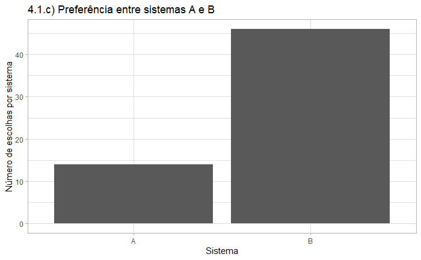

```r
library(ggplot2)
grafico4.1.c <- ggplot(prefsAB, aes(x=Pref))+  geom_bar() + theme_light()+ labs(x= "Sistema", y="Número de escolhas por sistema", title="4.1.c) Preferência entre sistemas A e B")


grafico4.1.c
```

**2- Problema: analisar as preferências de usuários entre três sistemas: prefsABC.cvs**

Desenvolvimento:

a)Hipóteses:

“Há diferença na preferência entre os sistemas A, B e C?”

b)Leitura dos dados:

```r
#A leitura dos dados é realizado excluindo-se a primeira coluna, pois se trata de um sequêncial sem significado para o problema em questão. Além disso é realizado o "factor" dos dados para que seja possível realizar a contagem dos valores
prefsABC <- as.tibble(read_csv("Dados/prefsABC.csv",col_types = cols(Pref = col_factor(levels = c("A","B","C")), Subject = col_skip())))
```

c)Geração de gráficos

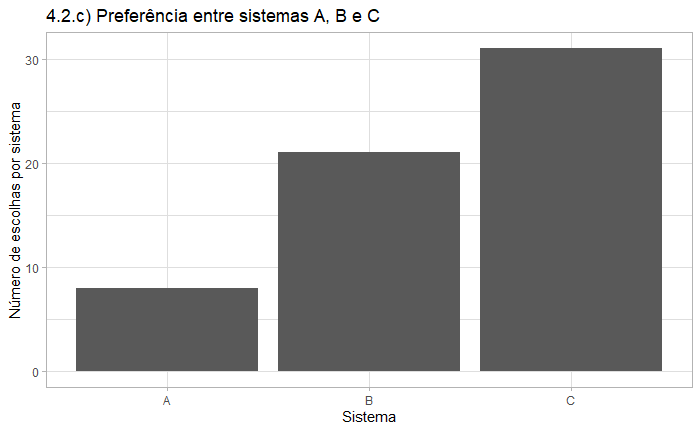

```r
grafico4.2.c <- ggplot(prefsABC, aes(x=Pref))+  geom_bar() + theme_light()+ labs(x= "Sistema", y="Número de escolhas por sistema", title="4.2.c) Preferência entre sistemas A, B e C")


grafico4.2.c
```

```r
NA
NA
NA
```

**3- Problema: analisar as preferências de usuários, por gênero, entre dois sistemas Amostra é prefsABsex.cvs**

Desenvolvimento:

a)Hipóteses:

“Há diferença na preferência do sistemas A por gênero?”

“Há diferença na preferência do sistemas B por gênero?”

b)Leitura dos dados:

```r
#A leitura dos dados é realizado excluindo-se a primeira coluna, pois se trata de um sequêncial sem significado para o problema em questão. Além disso é realizado o "factor" dos dados para que seja possível realizar a contagem dos valores
prefsABsex <- as.tibble(read_csv("Dados/prefsABsex.csv",
    col_types = cols(Pref = col_factor(levels = c("A",
        "B")),
        Sex = col_factor(levels = c("M", "F")),
        Subject = col_skip())))

#organização dos dados: agrupamento por preferência de sistema
tabelaPorPref.ABSex <- prefsABsex%>%
  group_by(Pref,Sex)%>%
  summarize(count = n())%>%
  spread(Sex, count)


print(tabelaPorPref.ABSex)
```

| Pref | M | F |
| --- | --- | --- |
| A | 12 | 2 |
| B | 17 | 29 |

```r
#organização dos dados: agrupamento por gênero do participante
tabelaPorSex.ABSex <- prefsABsex%>%
  group_by(Sex, Pref)%>%
  summarize(count = n())%>%
  spread(Pref, count)

print(tabelaPorSex.ABSex)
```

| Sex | A | B |
| --- | --- | --- |
| M | 12 | 17 |
| F | 2 | 29 |

```r
NA
```

c)Geração de gráficos

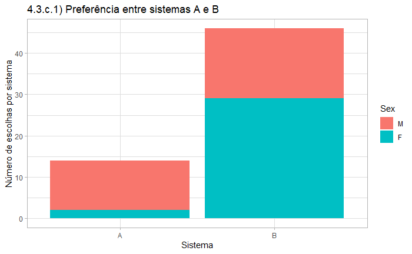

```r
grafico4.3.c.1 <- ggplot(prefsABsex, aes(x=Pref, fill = Sex))+  geom_bar() + theme_light()+ labs(x= "Sistema", y="Número de escolhas por sistema", title="4.3.c.1) Preferência entre sistemas A e B")


grafico4.3.c.2 <- ggplot(prefsABsex, aes(x=Sex, fill = Pref))+  geom_bar() + theme_light()+ labs(x= "Sistemas escolhidos por gênero", y="Número de escolhas por sistema", title="4.3.c.2) Preferência entre sistemas A e B")+facet_wrap(~Pref)

grafico4.3.c.1
```

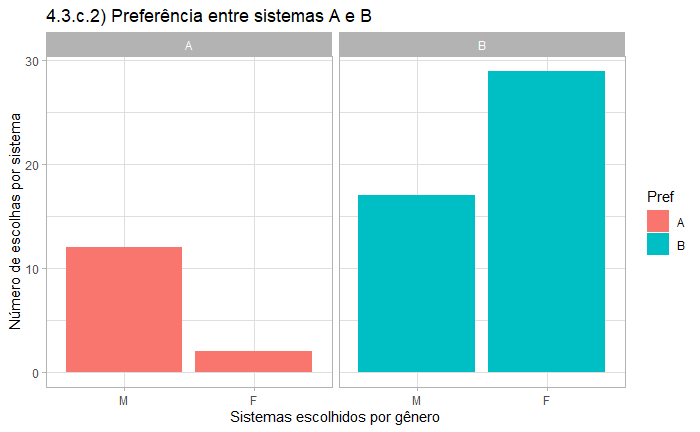

```r
grafico4.3.c.2
```